# Session7

```python
import pandas as pd
import numpy as np
df = pd.read_csv("campus.csv")
df
```

|  | enroll | priv | police | crime | lcrime | lenroll | lpolice |
| --- | --- | --- | --- | --- | --- | --- | --- |
| 0 | 21836 | 0 | 24 | 446 | 6.100319 | 9.991315 | 3.178054 |
| 1 | 6485 | 0 | 13 | 1 | 0.000000 | 8.777247 | 2.564949 |
| 2 | 2123 | 0 | 3 | 1 | 0.000000 | 7.660585 | 1.098612 |
| 3 | 8240 | 0 | 17 | 121 | 4.795791 | 9.016756 | 2.833213 |
| 4 | 19793 | 0 | 30 | 470 | 6.152733 | 9.893084 | 3.401197 |
| ... | ... | ... | ... | ... | ... | ... | ... |
| 92 | 3176 | 0 | 4 | 56 | 4.025352 | 8.063377 | 1.386294 |
| 93 | 10992 | 0 | 9 | 187 | 5.231109 | 9.304923 | 2.197225 |
| 94 | 5034 | 1 | 7 | 15 | 2.708050 | 8.523971 | 1.945910 |
| 95 | 7710 | 1 | 5 | 426 | 6.054439 | 8.950273 | 1.609438 |
| 96 | 20693 | 0 | 32 | 616 | 6.423247 | 9.937551 | 3.465736 |

97 rows × 7 columns

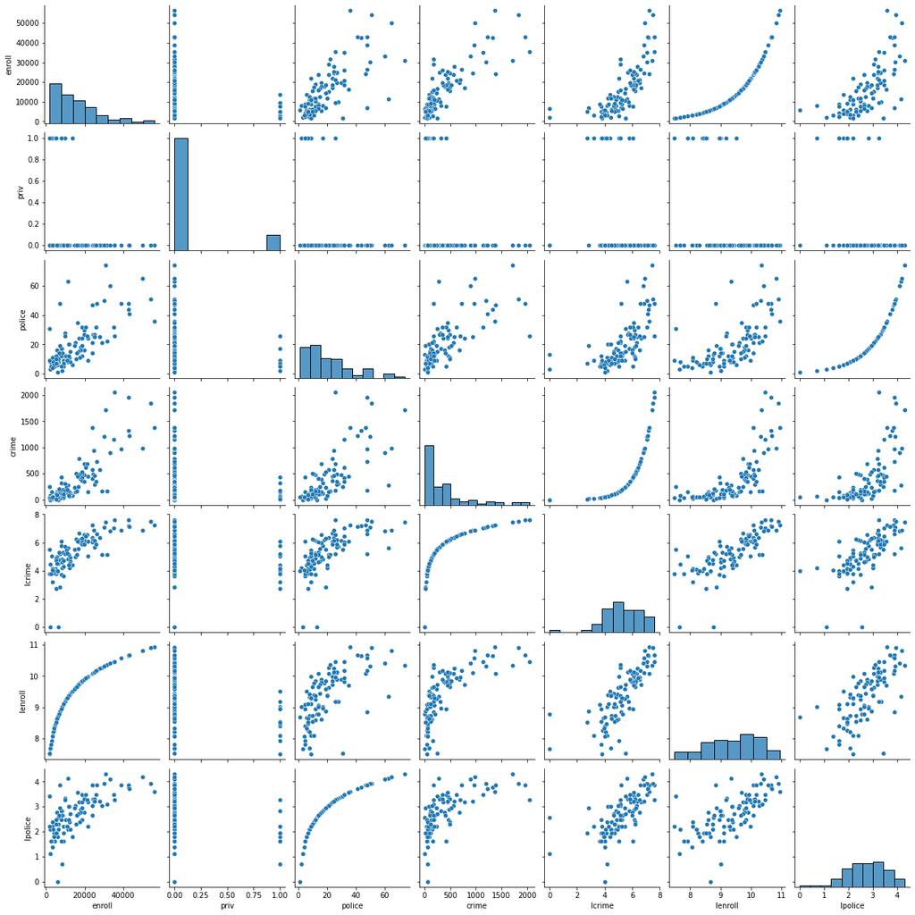

```python
import seaborn as sns
sns.pairplot(df)
```

```python
import statsmodels.api as sm
import statsmodels.formula.api as smf
mod = smf.ols(formula='crime ~ enroll + police + priv', data=df)
res = mod.fit()
print(res.summary())
```

```
                            OLS Regression Results
==============================================================================
Dep. Variable:                  crime   R-squared:                       0.734
Model:                            OLS   Adj. R-squared:                  0.725
Method:                 Least Squares   F-statistic:                     85.46
Date:                Tue, 15 Nov 2022   Prob (F-statistic):           1.25e-26
Time:                        18:13:53   Log-Likelihood:                -667.84
No. Observations:                  97   AIC:                             1344.
Df Residuals:                      93   BIC:                             1354.
Df Model:                           3
Covariance Type:            nonrobust
==============================================================================
                 coef    std err          t      P>|t|      [0.025      0.975]
------------------------------------------------------------------------------
Intercept   -174.0776     47.679     -3.651      0.000    -268.758     -79.397
enroll         0.0249      0.003      8.572      0.000       0.019       0.031
police         7.7866      2.267      3.434      0.001       3.284      12.289
priv          75.0596     78.575      0.955      0.342     -80.974     231.093
==============================================================================
Omnibus:                       38.266   Durbin-Watson:                   2.038
Prob(Omnibus):                  0.000   Jarque-Bera (JB):              155.503
Skew:                           1.189   Prob(JB):                     1.71e-34
Kurtosis:                       8.729   Cond. No.                     6.79e+04
==============================================================================

Notes:
[1] Standard Errors assume that the covariance matrix of the errors is correctly specified.
[2] The condition number is large, 6.79e+04. This might indicate that there are
strong multicollinearity or other numerical problems.
```

```python
mod = smf.ols(formula='crime ~ enroll', data=df)
res = mod.fit()
print(res.summary())
```

```
                            OLS Regression Results
==============================================================================
Dep. Variable:                  crime   R-squared:                       0.699
Model:                            OLS   Adj. R-squared:                  0.696
Method:                 Least Squares   F-statistic:                     220.6
Date:                Tue, 15 Nov 2022   Prob (F-statistic):           1.67e-26
Time:                        18:30:08   Log-Likelihood:                -673.80
No. Observations:                  97   AIC:                             1352.
Df Residuals:                      95   BIC:                             1357.
Df Model:                           1
Covariance Type:            nonrobust
==============================================================================
                 coef    std err          t      P>|t|      [0.025      0.975]
------------------------------------------------------------------------------
Intercept   -109.0989     42.607     -2.561      0.012    -193.685     -24.513
enroll         0.0313      0.002     14.852      0.000       0.027       0.036
==============================================================================
Omnibus:                       34.521   Durbin-Watson:                   1.809
Prob(Omnibus):                  0.000   Jarque-Bera (JB):              111.356
Skew:                           1.146   Prob(JB):                     6.60e-25
Kurtosis:                       7.722   Cond. No.                     3.34e+04
==============================================================================

Notes:
[1] Standard Errors assume that the covariance matrix of the errors is correctly specified.
[2] The condition number is large, 3.34e+04. This might indicate that there are
strong multicollinearity or other numerical problems.
```

R sqaure is always increasing when we put in more variables  
The condition number above is likely caused by multicolinearity  
Multicolinearity will increase the variance/std err of $\beta$ hence decrease statisitical significance

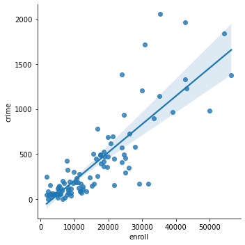

```python
#Choose between linear or log-linear model
sns.lmplot(x='enroll',y='crime',data=df)
```

The equation for log-lieanr : $ log(y) = \beta_0 +\beta_1 log(x)=log(e^{\beta_0}x^{\beta_1}) $

it is equivaluent to: $ y=e^{\beta_0}x^{\beta_1}$

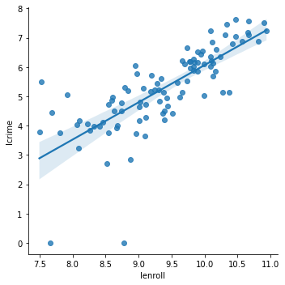

```python
sns.lmplot(x='lenroll',y='lcrime',data=df)
```

Comparing two graphs, it is difficult to say which model is better.  
Another problem not shown is heteroscedasticity.  
This problem will make estimator indefficient. Still unbiased though.  
Inefficient means the sum of sqaure error is not minimized.

Another problem is heteroscedasticity.  
(standard deviations correlated with x)

```python
from statsmodels.regression.linear_model import GLS
import seaborn as sns
dfy=df['crime']
dfx=sm.add_constant(df['enroll'])
ols_resid = sm.OLS(df['crime'],sm.add_constant(df['enroll'])).fit().resid
logres=np.log(ols_resid**2)
res_fit = sm.OLS(logres, dfx).fit()
sigma=res_fit.predict()
weight=1/np.exp(sigma/2)
#weight=np.diag(np.exp(sigma/2))
#This is one way to do FGLS, you may use it in your project.
#It doesn't make much difference in this data set.
mod = GLS(df['crime'],sm.add_constant(df['enroll']),weight)
res = mod.fit()
print(res.summary())
#This is also a way to handle data with Autoregressive process
#eg. A time series data where each dependent variable of this year may have corrlated with its value of last year
```

[output not shown]

```python
#mod = smf.ols(formula='crime ~ priv', data=df)
#res = mod.fit()
#print(res.summary())

#The code above and below do the same thing
mod = sm.OLS(df['crime'],sm.add_constant(df['priv']))
res = mod.fit()
print(res.summary())
```

```
                            OLS Regression Results
==============================================================================
Dep. Variable:                  crime   R-squared:                       0.050
Model:                            OLS   Adj. R-squared:                  0.040
Method:                 Least Squares   F-statistic:                     4.954
Date:                Tue, 15 Nov 2022   Prob (F-statistic):             0.0284
Time:                        18:57:31   Log-Likelihood:                -729.56
No. Observations:                  97   AIC:                             1463.
Df Residuals:                      95   BIC:                             1468.
Df Model:                           1
Covariance Type:            nonrobust
==============================================================================
                 coef    std err          t      P>|t|      [0.025      0.975]
------------------------------------------------------------------------------
const        432.8000     48.980      8.836      0.000     335.562     530.038
priv        -309.9667    139.257     -2.226      0.028    -586.427     -33.506
==============================================================================
Omnibus:                       42.780   Durbin-Watson:                   1.870
Prob(Omnibus):                  0.000   Jarque-Bera (JB):               87.196
Skew:                           1.789   Prob(JB):                     1.16e-19
Kurtosis:                       5.963   Cond. No.                         3.09
==============================================================================

Notes:
[1] Standard Errors assume that the covariance matrix of the errors is correctly specified.
```

From the regression result above, can we says that private school cause less crime? Endogeneity problem and ommited variable bias

When we propose a model that ignore an variable that is correlated to both dependent and independent variable,  
the estimator will be baised. We are not going to proof it here but you can see this example.  
Public school has higher enrollment number and enrollment is correlated with crime number.  
Then, by omitted enroll number, we will get some wrong estimator.  
How to avoid or fix these problems? Instrument Variables or 2SLS.  
IV need to be correlated with X but not correlated with Y  
How to find instrument variable? Difficult to find and test. (J test/Sargan–Hansen test can only rule out some cases)

```python
mod = smf.ols(formula='enroll ~ priv', data=df)
res = mod.fit()
print(res.summary())
```

```
                            OLS Regression Results
==============================================================================
Dep. Variable:                 enroll   R-squared:                       0.092
Model:                            OLS   Adj. R-squared:                  0.083
Method:                 Least Squares   F-statistic:                     9.660
Date:                Tue, 15 Nov 2022   Prob (F-statistic):            0.00249
Time:                        19:01:54   Log-Likelihood:                -1045.9
No. Observations:                  97   AIC:                             2096.
Df Residuals:                      95   BIC:                             2101.
Df Model:                           1
Covariance Type:            nonrobust
==============================================================================
                 coef    std err          t      P>|t|      [0.025      0.975]
------------------------------------------------------------------------------
Intercept   1.747e+04   1277.632     13.676      0.000    1.49e+04       2e+04
priv       -1.129e+04   3632.462     -3.108      0.002   -1.85e+04   -4078.330
==============================================================================
Omnibus:                       22.262   Durbin-Watson:                   1.718
Prob(Omnibus):                  0.000   Jarque-Bera (JB):               29.042
Skew:                           1.158   Prob(JB):                     4.94e-07
Kurtosis:                       4.351   Cond. No.                         3.09
==============================================================================

Notes:
[1] Standard Errors assume that the covariance matrix of the errors is correctly specified.
```

```python
mod = smf.ols(formula='crime ~ enroll + priv', data=df)
res = mod.fit()
print(res.summary())
```

```
                            OLS Regression Results
==============================================================================
Dep. Variable:                  crime   R-squared:                       0.700
Model:                            OLS   Adj. R-squared:                  0.694
Method:                 Least Squares   F-statistic:                     109.7
Date:                Tue, 15 Nov 2022   Prob (F-statistic):           2.64e-25
Time:                        18:57:58   Log-Likelihood:                -673.63
No. Observations:                  97   AIC:                             1353.
Df Residuals:                      94   BIC:                             1361.
Df Model:                           2
Covariance Type:            nonrobust
==============================================================================
                 coef    std err          t      P>|t|      [0.025      0.975]
------------------------------------------------------------------------------
Intercept   -121.3695     47.662     -2.546      0.013    -216.003     -26.736
enroll         0.0317      0.002     14.278      0.000       0.027       0.036
priv          48.0939     82.548      0.583      0.562    -115.806     211.994
==============================================================================
Omnibus:                       34.491   Durbin-Watson:                   1.810
Prob(Omnibus):                  0.000   Jarque-Bera (JB):              112.381
Skew:                           1.141   Prob(JB):                     3.95e-25
Kurtosis:                       7.754   Cond. No.                     6.71e+04
==============================================================================

Notes:
[1] Standard Errors assume that the covariance matrix of the errors is correctly specified.
[2] The condition number is large, 6.71e+04. This might indicate that there are
strong multicollinearity or other numerical problems.
```

```python
from statsmodels.sandbox.regression.gmm import IV2SLS
dfy=df['crime']
dfx=sm.add_constant(df['priv'])
dfi=df[['police','enroll']]
mod = IV2SLS(dfy,dfx,dfi)
res = mod.fit()
print(res.summary())
#This is just an sample in case you would like to use in project.
#Since police and enroll is correlated with crime, they are not valid instrument variables.
```

```
                          IV2SLS Regression Results
==============================================================================
Dep. Variable:                  crime   R-squared:                     -28.251
Model:                         IV2SLS   Adj. R-squared:                -28.558
Method:                     Two Stage   F-statistic:                   0.07558
                        Least Squares   Prob (F-statistic):              0.784
Date:                Tue, 15 Nov 2022
Time:                        18:13:54
No. Observations:                  97
Df Residuals:                      95
Df Model:                           1
==============================================================================
                 coef    std err          t      P>|t|      [0.025      0.975]
------------------------------------------------------------------------------
const       1050.7705   1434.254      0.733      0.466   -1796.583    3898.124
priv       -7663.2834   2.79e+04     -0.275      0.784    -6.3e+04    4.77e+04
==============================================================================
Omnibus:                       50.048   Durbin-Watson:                   1.450
Prob(Omnibus):                  0.000   Jarque-Bera (JB):              107.643
Skew:                           2.151   Prob(JB):                     4.22e-24
Kurtosis:                       5.852   Cond. No.                         3.09
==============================================================================
```

```python
#A logit model
from statsmodels.discrete.discrete_model import Logit
dfy = df['priv']
dfx1 = sm.add_constant(df[['crime','police','enroll']])
dfx2 = sm.add_constant(df[['enroll']])
mod1 = Logit(dfy,dfx1)
res1 = mod1.fit()
mod2 = Logit(dfy,dfx2)
res2 = mod2.fit()
print(res1.summary())
print(res2.summary())
#Which one is better? Why?
```

```
Optimization terminated successfully.
         Current function value: 0.279196
         Iterations 9
Optimization terminated successfully.
         Current function value: 0.292917
         Iterations 8
                           Logit Regression Results
==============================================================================
Dep. Variable:                   priv   No. Observations:                   97
Model:                          Logit   Df Residuals:                       93
Method:                           MLE   Df Model:                            3
Date:                Tue, 15 Nov 2022   Pseudo R-squ.:                  0.2540
Time:                        18:13:54   Log-Likelihood:                -27.082
converged:                       True   LL-Null:                       -36.303
Covariance Type:            nonrobust   LLR p-value:                 0.0003566
==============================================================================
                 coef    std err          z      P>|z|      [0.025      0.975]
------------------------------------------------------------------------------
const          0.6881      0.752      0.915      0.360      -0.786       2.162
crime          0.0025      0.003      0.841      0.400      -0.003       0.008
police        -0.0891      0.066     -1.358      0.174      -0.218       0.039
enroll        -0.0002      0.000     -1.888      0.059      -0.000     7.9e-06
==============================================================================
                           Logit Regression Results
==============================================================================
Dep. Variable:                   priv   No. Observations:                   97
Model:                          Logit   Df Residuals:                       95
Method:                           MLE   Df Model:                            1
Date:                Tue, 15 Nov 2022   Pseudo R-squ.:                  0.2173
Time:                        18:13:54   Log-Likelihood:                -28.413
converged:                       True   LL-Null:                       -36.303
Covariance Type:            nonrobust   LLR p-value:                 7.116e-05
==============================================================================
                 coef    std err          z      P>|z|      [0.025      0.975]
------------------------------------------------------------------------------
const          0.0953      0.625      0.153      0.879      -1.129       1.320
enroll        -0.0002   7.79e-05     -2.693      0.007      -0.000    -5.7e-05
==============================================================================
```

```python
#The next session use the tips dataset
import seaborn as sns
tips = sns.load_dataset("tips")
tips['tip_percent']=tips['tip']/tips['total_bill']
tips['average_bill']=tips['total_bill']/tips['size']
tips['weekends']=[1 if i in ['Sun','Sat'] else 0 for i in tips['day']]
tips['tip_per_guest']=tips['tip']/tips['size']
tips
```

|  | total_bill | tip | sex | smoker | day | time | size | tip_percent | average_bill | weekends | tip_per_guest |
| --- | --- | --- | --- | --- | --- | --- | --- | --- | --- | --- | --- |
| 0 | 16.99 | 1.01 | Female | No | Sun | Dinner | 2 | 0.059447 | 8.495000 | 1 | 0.505000 |
| 1 | 10.34 | 1.66 | Male | No | Sun | Dinner | 3 | 0.160542 | 3.446667 | 1 | 0.553333 |
| 2 | 21.01 | 3.50 | Male | No | Sun | Dinner | 3 | 0.166587 | 7.003333 | 1 | 1.166667 |
| 3 | 23.68 | 3.31 | Male | No | Sun | Dinner | 2 | 0.139780 | 11.840000 | 1 | 1.655000 |
| 4 | 24.59 | 3.61 | Female | No | Sun | Dinner | 4 | 0.146808 | 6.147500 | 1 | 0.902500 |
| ... | ... | ... | ... | ... | ... | ... | ... | ... | ... | ... | ... |
| 239 | 29.03 | 5.92 | Male | No | Sat | Dinner | 3 | 0.203927 | 9.676667 | 1 | 1.973333 |
| 240 | 27.18 | 2.00 | Female | Yes | Sat | Dinner | 2 | 0.073584 | 13.590000 | 1 | 1.000000 |
| 241 | 22.67 | 2.00 | Male | Yes | Sat | Dinner | 2 | 0.088222 | 11.335000 | 1 | 1.000000 |
| 242 | 17.82 | 1.75 | Male | No | Sat | Dinner | 2 | 0.098204 | 8.910000 | 1 | 0.875000 |
| 243 | 18.78 | 3.00 | Female | No | Thur | Dinner | 2 | 0.159744 | 9.390000 | 0 | 1.500000 |

244 rows × 11 columns

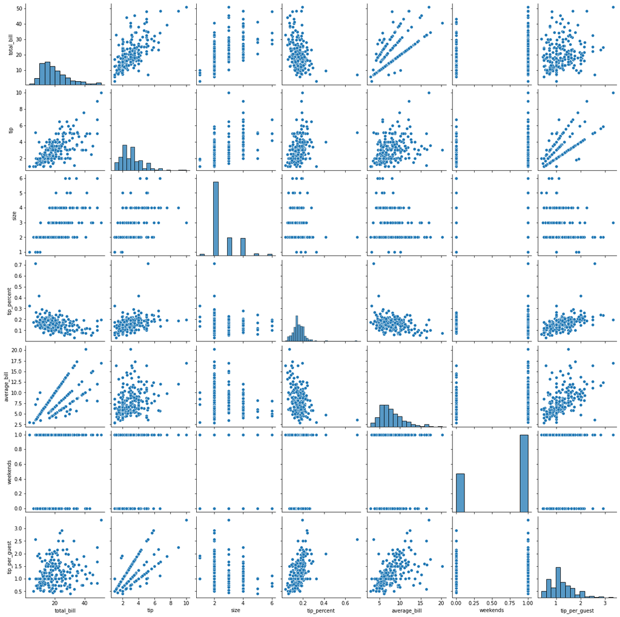

```python
sns.pairplot(tips)
```

```python
#An sample question: does automatic gratuity placed on large dining parties make sense?
mod = smf.ols(formula='tip_percent ~ size', data=tips)
res = mod.fit()
print(res.summary())
```

```
                            OLS Regression Results
==============================================================================
Dep. Variable:            tip_percent   R-squared:                       0.020
Model:                            OLS   Adj. R-squared:                  0.016
Method:                 Least Squares   F-statistic:                     5.042
Date:                Tue, 15 Nov 2022   Prob (F-statistic):             0.0256
Time:                        18:13:58   Log-Likelihood:                 338.95
No. Observations:                 244   AIC:                            -673.9
Df Residuals:                     242   BIC:                            -666.9
Df Model:                           1
Covariance Type:            nonrobust
==============================================================================
                 coef    std err          t      P>|t|      [0.025      0.975]
------------------------------------------------------------------------------
Intercept      0.1844      0.011     16.475      0.000       0.162       0.206
size          -0.0092      0.004     -2.245      0.026      -0.017      -0.001
==============================================================================
Omnibus:                      220.122   Durbin-Watson:                   2.096
Prob(Omnibus):                  0.000   Jarque-Bera (JB):             7618.220
Skew:                           3.308   Prob(JB):                         0.00
Kurtosis:                      29.562   Cond. No.                         8.85
==============================================================================

Notes:
[1] Standard Errors assume that the covariance matrix of the errors is correctly specified.
```

```python
#What about absolute value, maybe guest in large party pay less because their bill is larger
mod = smf.ols(formula='tip_per_guest ~ size', data=tips)
res = mod.fit()
print(res.summary())
```

```
                            OLS Regression Results
==============================================================================
Dep. Variable:          tip_per_guest   R-squared:                       0.064
Model:                            OLS   Adj. R-squared:                  0.060
Method:                 Least Squares   F-statistic:                     16.64
Date:                Tue, 15 Nov 2022   Prob (F-statistic):           6.15e-05
Time:                        18:13:58   Log-Likelihood:                -164.40
No. Observations:                 244   AIC:                             332.8
Df Residuals:                     242   BIC:                             339.8
Df Model:                           1
Covariance Type:            nonrobust
==============================================================================
                 coef    std err          t      P>|t|      [0.025      0.975]
------------------------------------------------------------------------------
Intercept      1.5497      0.088     17.598      0.000       1.376       1.723
size          -0.1311      0.032     -4.079      0.000      -0.194      -0.068
==============================================================================
Omnibus:                       49.681   Durbin-Watson:                   1.760
Prob(Omnibus):                  0.000   Jarque-Bera (JB):               85.327
Skew:                           1.095   Prob(JB):                     2.96e-19
Kurtosis:                       4.897   Cond. No.                         8.85
==============================================================================

Notes:
[1] Standard Errors assume that the covariance matrix of the errors is correctly specified.
```

```python
#Do people be more generous at weekends?
mod = smf.ols(formula='tip_percent ~ weekends', data=tips)
res = mod.fit()
print(res.summary())
```

```
                            OLS Regression Results
==============================================================================
Dep. Variable:            tip_percent   R-squared:                       0.001
Model:                            OLS   Adj. R-squared:                 -0.003
Method:                 Least Squares   F-statistic:                    0.2024
Date:                Tue, 15 Nov 2022   Prob (F-statistic):              0.653
Time:                        18:13:58   Log-Likelihood:                 336.53
No. Observations:                 244   AIC:                            -669.1
Df Residuals:                     242   BIC:                            -662.1
Df Model:                           1
Covariance Type:            nonrobust
==============================================================================
                 coef    std err          t      P>|t|      [0.025      0.975]
------------------------------------------------------------------------------
Intercept      0.1633      0.007     24.026      0.000       0.150       0.177
weekends      -0.0037      0.008     -0.450      0.653      -0.020       0.013
==============================================================================
Omnibus:                      222.700   Durbin-Watson:                   2.066
Prob(Omnibus):                  0.000   Jarque-Bera (JB):             7798.936
Skew:                           3.367   Prob(JB):                         0.00
Kurtosis:                      29.866   Cond. No.                         3.23
==============================================================================

Notes:
[1] Standard Errors assume that the covariance matrix of the errors is correctly specified.
```

Some problem if you are interested in econometric  
Problem with significance(only result with significance attract attention)  
Problem of retrospetive(summarizing past data) vs. prospective(predicting future data)